# Deep Learning Project: Pet Classifier using CNN

Prepration

- Extract the ipynb file and the data in the same folder

Data Set

- A production grade program as 10,000 training images
- This is a small program with 20 images of cats and 20 images of dogs.
- The evaluation set has 10 images of cats and 10 images of dogs

Runs

- The student is expected to run the 100-300 training step
- A production grade code would have about 20k-50k training steps

### Import modules

```python
from __future__ import absolute_import
from __future__ import division
from __future__ import print_function
# To support both python 2 and python 3
from __future__ import division, print_function, unicode_literals
import os
import cv2
import glob
import matplotlib.pyplot as plt
import numpy as np
import tensorflow as tf
import random
import sys

# to make this notebook's output stable across runs
def reset_graph(seed=42):
    tf.reset_default_graph()
    tf.set_random_seed(seed)
    np.random.seed(seed)
```

### Set hyper parameters

- Run the program with three num_steps : 100,200,300

```python
reset_graph()

img_size = 32
num_channels = 3
img_size_flat = img_size * img_size * num_channels
img_shape = (img_size, img_size)
trainpath='D://SimpliLearn Projects//Deep Learning\Deep Learning course - Capstone Project//Deep Learning course - Capstone Project//data//train//'
testpath='D://SimpliLearn Projects//Deep Learning\Deep Learning course - Capstone Project//Deep Learning course - Capstone Project//data//test//'
labels = {'cats': 0, 'dogs': 1}
fc_size=32 #size of the output of final FC layer
num_steps=300 #Try 100, 200, 300. number of steps that training data should be looped. Usually 20K
tf.logging.set_verbosity(tf.logging.INFO)
```

### Read the image dataset

```
length of train image set 40
X_data shape: (40, 32, 32, 3)
y_data shape: (40,)
```

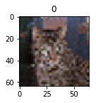

```python
def read_images_classes(basepath,imgSize=img_size):
    image_stack = []
    label_stack = []

    for counter, l in enumerate(labels):
        path = os.path.join(basepath, l,'*g')
        for img in glob.glob(path):
            one_hot_vector =np.zeros(len(labels),dtype=np.int16)
            one_hot_vector[counter]=1
            image = cv2.imread(img)
            im_resize = cv2.resize(image,img_shape, interpolation=cv2.INTER_CUBIC)
            image_stack.append(im_resize)
            label_stack.append(labels[l])
    return np.array(image_stack), np.array(label_stack)

X_train, y_train=read_images_classes(trainpath)
X_test, y_test=read_images_classes(testpath)

#test a sample image
print('length of train image set',len(X_train))
print('X_data shape:', X_train.shape)
print('y_data shape:', y_train.shape)

fig1 = plt.figure()
ax1 = fig1.add_subplot(2,2,1)
img = cv2.resize(X_train[0],(64,64), interpolation=cv2.INTER_CUBIC)
ax1.imshow(cv2.cvtColor(img, cv2.COLOR_BGR2RGB))
plt.title(y_train[0])
plt.show()
```

### Assignment: Define the tensorflow model

The model should have the following layers

- input later
- conv layer 1 with 32 filters of kernel size[5,5],
- pooling layer 1 with pool size[2,2] and stride 2
- conv layer 2 with 64 filters of kernel size[5,5],
- pooling layer 2 with pool size[2,2] and stride 2
- dense layer whose output size is fixed in the hyper parameter: fc_size=32
- drop out layer with droput probability 0.4
- predict the class by doing a softmax on the output of the dropout layers

Training

- For training fefine the loss function and minimize it
- For evaluation calculate the accuracy

Reading Material

- For ideas look at tensorflow layers tutorial

### The cnn_model_fn has to be defined here by the student

```python
def cnn_model_fn(features, labels, mode):
    inputLayer = tf.reshape(features['x'],[-1, img_size, img_size, num_channels])

    conv1 = tf.layers.conv2d(inputLayer, filters=32, kernel_size=[5,5],
                         strides=1, padding="SAME",
                         activation=tf.nn.relu, name="conv1")

    pool1 = tf.layers.max_pooling2d(conv1, pool_size=[2,2], strides=2)

    conv2 = tf.layers.conv2d(pool1, filters=64, kernel_size=[5,5],
                         strides=1, padding="SAME",
                         activation=tf.nn.relu, name="conv2")

    pool2 = tf.layers.max_pooling2d(conv2, pool_size=[2,2], strides=2)

    pool2layershape = pool2.get_shape()
    num_features = pool2layershape[1:4].num_elements()
    print("total number of features in pool2 is: ", num_features)
    pool2flattened = tf.reshape(pool2, [-1, num_features])

    #fully connected layer with fc_size 32
    fclayer = tf.layers.dense(inputs=pool2flattened, units=fc_size, activation=tf.nn.relu)
    print("FC Layer : ", fclayer.get_shape())

    #create dropout layer
    dropout = tf.layers.dropout(inputs=fclayer, rate=0.4, training=mode==tf.estimator.ModeKeys.TRAIN)

    #output layer
    logits = tf.layers.dense(inputs=dropout, units=2)

    #predictions
    predictions = {'classes': tf.argmax(input=logits, axis=1),
                  'probabilities': tf.nn.softmax(logits, name='softmax_tensor')}

    #predict method
    if mode == tf.estimator.ModeKeys.PREDICT:
        return tf.estimator.EstimatorSpec(mode, predictions=predictions)

    #calculate loss
    onehot_label = tf.one_hot(indices=tf.cast(labels, tf.int32), depth=2)
    loss = tf.losses.softmax_cross_entropy(onehot_labels=onehot_label, logits=logits)

    #training operation
    if mode == tf.estimator.ModeKeys.TRAIN:
        optimizer = tf.train.GradientDescentOptimizer(learning_rate=0.01)
        train_op = optimizer.minimize(loss=loss, global_step=tf.train.get_global_step())
        return tf.estimator.EstimatorSpec(mode=mode, loss=loss, train_op=train_op)

    #eval
    eval_metric_ops = {'accuracy': tf.metrics.accuracy(labels, predictions['classes'])}
    return tf.estimator.EstimatorSpec(mode=mode, loss=loss, eval_metric_ops=eval_metric_ops)
```

### Run the tensorflow model

This section will use the model defined by the student and run the training and evaluation step

```python
#X_train = np.array((X_train/255.0),dtype=np.float16)
#X_test = np.array((X_test/255.0), dtype=np.float16)
X_train = np.array((X_train/255.0),dtype=np.float32)
X_test = np.array((X_test/255.0), dtype=np.float32)

pets_classifier = tf.estimator.Estimator(model_fn=cnn_model_fn, model_dir="/tmp/pets_convnet_model")
#pets_classifier = tf.estimator.Estimator(model_fn=cnn_model_fn)
tensors_to_log = {"probabilities": "softmax_tensor"}
logging_hook = tf.train.LoggingTensorHook(tensors=tensors_to_log, every_n_iter=50)
train_input_fn = tf.estimator.inputs.numpy_input_fn(x={"x": X_train}, y=y_train, batch_size=10,
                                                      num_epochs=None, shuffle=True)
pets_classifier.train(input_fn=train_input_fn, steps=num_steps, hooks=[logging_hook])
eval_input_fn = tf.estimator.inputs.numpy_input_fn(x={"x": X_test}, y=y_test, num_epochs=1,shuffle=False)
eval_results = pets_classifier.evaluate(input_fn=eval_input_fn)
print(eval_results)
```

[output not shown]

[output cut: 79 more lines]

```
INFO:tensorflow:Saving checkpoints for 900 into /tmp/pets_convnet_model\model.ckpt.
INFO:tensorflow:Loss for final step: 0.47595486.
INFO:tensorflow:Calling model_fn.
total number of features in pool2 is:  4096
FC Layer :  (?, 32)
INFO:tensorflow:Done calling model_fn.
INFO:tensorflow:Starting evaluation at 2019-06-09T14:15:45Z
INFO:tensorflow:Graph was finalized.
INFO:tensorflow:Restoring parameters from /tmp/pets_convnet_model\model.ckpt-900
INFO:tensorflow:Running local_init_op.
INFO:tensorflow:Done running local_init_op.
INFO:tensorflow:Finished evaluation at 2019-06-09-14:15:46
INFO:tensorflow:Saving dict for global step 900: accuracy = 0.65, global_step = 900, loss = 0.6902549
INFO:tensorflow:Saving 'checkpoint_path' summary for global step 900: /tmp/pets_convnet_model\model.ckpt-900
{'accuracy': 0.65, 'loss': 0.6902549, 'global_step': 900}
```